# Real-world Data Wrangling

In this project, you will apply the skills you acquired in the course to gather and wrangle real-world data with two datasets of your choice.

You will retrieve and extract the data, assess the data programmatically and visually, accross elements of data quality and structure, and implement a cleaning strategy for the data. You will then store the updated data into your selected database/data store, combine the data, and answer a research question with the datasets.

Throughout the process, you are expected to:

1. Explain your decisions towards methods used for gathering, assessing, cleaning, storing, and answering the research question
2. Write code comments so your code is more readable

## 1. Gather data

In this section, you will extract data using two different data gathering methods and combine the data. Use at least two different types of data-gathering methods.

### **1.1.** Problem Statement

In 2-4 sentences, explain the kind of problem you want to look at and the datasets you will be wrangling for this project.

In this project, we will work with two datasets from Kaggle: *TMDB 5000 Movies* and *TMDB 5000 Credits*. Our analysis will focus on exploring the correlation between various movie attribute, such as budget, genres, and cast information as well as key indicators of movie success, including revenue and ratings. Additionally, we will investigate factors that may influence a movie's popularity.

### **1.2.** Gather at least two datasets using two different data gathering methods

List of data gathering methods:

- Download data manually
- Programmatically downloading files
- Gather data by accessing APIs
- Gather and extract data from HTML files using BeautifulSoup
- Extract data from a SQL database

Each dataset must have at least two variables, and have greater than 500 data samples within each dataset.

For each dataset, briefly describe why you picked the dataset and the gathering method (2-3 full sentences), including the names and significance of the variables in the dataset. Show your work (e.g., if using an API to download the data, please include a snippet of your code).

Load the dataset programmtically into this notebook.

```python
# Load all the necessary packages
import os
import requests
import zipfile
import pandas as pd
import json
import matplotlib.pyplot as plt
%matplotlib inline
import seaborn as sns
sns.set(rc={'figure.figsize': [15, 8]}, font_scale=1.2)
```

#### **Dataset 1: TMDB 5000 Movies**

Type: CSV File

Method: The dataset was gathered using the "API" and programmatically downloaded from Kaggle.This dataset contains 4803 movies from TMDB, containg information about various attributes related to movies and movie success.

Dataset variables:

- *Variable 1 budget*
- *Variable 2 genres*
- *Variable 3 homepage*
- *Variable 4 id*
- *Variable 5 keywords*
- *Variable 6 original_language*
- *Variable 7 original_title*
- *Variable 8 overview*
- *Variable 9 popularity*
- *Variable 10 production_companies*
- *Variable 11 production_countries*
- *Variable 12 release_date*
- *Variable 13 revenue*
- *Variable 14 runtime*
- *Variable 15 spoken_languages*
- *Variable 16 status*
- *Variable 17 tagline*
- *Variable 18 title*
- *Variable 19 vote_average*
- *Variable 20 vote_count*

The URL

https://www.kaggle.com/api/v1/datasets/download/tmdb/tmdb-movie-metadata/tmdb_5000_movies.csv

```python
#decalre the dataset's url
dataset_path = "tmdb/tmdb-movie-metadata"
fite_name = "tmdb_5000_movies.csv"
dataset_url = f"https://www.kaggle.com/api/v1/datasets/download/{dataset_path}/{fite_name}"
data_sets_folder_name="data_sets"

#make HTTP get request to get the file using the url
get_file_response = requests.get(dataset_url)
#raise an expetion if happens
get_file_response.raise_for_status()

local_file_path = os.path.join(data_sets_folder_name, dataset_url.split('/')[-1])
zip_file_path = os.path.join(data_sets_folder_name, "dataset.zip")

with open(zip_file_path, mode = 'wb') as file:
    file.write(get_file_response.content)

with zipfile.ZipFile(zip_file_path, 'r') as zip_ref:
    zip_ref.extractall(data_sets_folder_name)

# Clean up: delete the not needed zip file
os.remove(zip_file_path)
```

```python
#Load the programmatically downloaded file to a dataframe
movies_df =  pd.read_csv(local_file_path)

#display a few recoeds
movies_df.head(2)
```

|  | budget | genres | homepage | id | keywords | original_language | original_title | overview | popularity | production_companies | production_countries | release_date | revenue | runtime | spoken_languages | status | tagline | title | vote_average | vote_count |
| --- | --- | --- | --- | --- | --- | --- | --- | --- | --- | --- | --- | --- | --- | --- | --- | --- | --- | --- | --- | --- |
| 0 | 237000000 | [{"id": 28, "name": "Action"}, {"id": 12, "nam... | http://www.avatarmovie.com/ | 19995 | [{"id": 1463, "name": "culture clash"}, {"id":... | en | Avatar | In the 22nd century, a paraplegic Marine is di... | 150.437577 | [{"name": "Ingenious Film Partners", "id": 289... | [{"iso_3166_1": "US", "name": "United States o... | 2009-12-10 | 2787965087 | 162.0 | [{"iso_639_1": "en", "name": "English"}, {"iso... | Released | Enter the World of Pandora. | Avatar | 7.2 | 11800 |
| 1 | 300000000 | [{"id": 12, "name": "Adventure"}, {"id": 14, "... | http://disney.go.com/disneypictures/pirates/ | 285 | [{"id": 270, "name": "ocean"}, {"id": 726, "na... | en | Pirates of the Caribbean: At World's End | Captain Barbossa, long believed to be dead, ha... | 139.082615 | [{"name": "Walt Disney Pictures", "id": 2}, {"... | [{"iso_3166_1": "US", "name": "United States o... | 2007-05-19 | 961000000 | 169.0 | [{"iso_639_1": "en", "name": "English"}] | Released | At the end of the world, the adventure begins. | Pirates of the Caribbean: At World's End | 6.9 | 4500 |

#### **Dataset 2 TMDB 5000 Credits**

Type: CSV File

Method: The dataset was manually downloaded from Kaggle

Dataset variables:

- *Variable 1 movie_id*
- *Variable 2 title*
- *Variable 3 cast*
- *Variable 4 crew*

```python
# gathered and downloaded manually from kaggle
credits_df= pd.read_csv('tmdb_5000_credits.csv')
credits_df.head()
```

|  | movie_id | title | cast | crew |
| --- | --- | --- | --- | --- |
| 0 | 19995 | Avatar | [{"cast_id": 242, "character": "Jake Sully", "... | [{"credit_id": "52fe48009251416c750aca23", "de... |
| 1 | 285 | Pirates of the Caribbean: At World's End | [{"cast_id": 4, "character": "Captain Jack Spa... | [{"credit_id": "52fe4232c3a36847f800b579", "de... |
| 2 | 206647 | Spectre | [{"cast_id": 1, "character": "James Bond", "cr... | [{"credit_id": "54805967c3a36829b5002c41", "de... |
| 3 | 49026 | The Dark Knight Rises | [{"cast_id": 2, "character": "Bruce Wayne / Ba... | [{"credit_id": "52fe4781c3a36847f81398c3", "de... |
| 4 | 49529 | John Carter | [{"cast_id": 5, "character": "John Carter", "c... | [{"credit_id": "52fe479ac3a36847f813eaa3", "de... |

## 2. Assess data

Assess the data according to data quality and tidiness metrics using the report below.

List **two** data quality issues and **two** tidiness issues. Assess each data issue visually **and** programmatically, then briefly describe the issue you find. **Make sure you include justifications for the methods you use for the assessment.**

### Quality Issue 1: Missing values

```python
# Inspecting the dataframe visually
movies_df.head()
```

|  | budget | genres | homepage | id | keywords | original_language | original_title | overview | popularity | production_companies | production_countries | release_date | revenue | runtime | spoken_languages | status | tagline | title | vote_average | vote_count |
| --- | --- | --- | --- | --- | --- | --- | --- | --- | --- | --- | --- | --- | --- | --- | --- | --- | --- | --- | --- | --- |
| 0 | 237000000 | [{"id": 28, "name": "Action"}, {"id": 12, "nam... | http://www.avatarmovie.com/ | 19995 | [{"id": 1463, "name": "culture clash"}, {"id":... | en | Avatar | In the 22nd century, a paraplegic Marine is di... | 150.437577 | [{"name": "Ingenious Film Partners", "id": 289... | [{"iso_3166_1": "US", "name": "United States o... | 2009-12-10 | 2787965087 | 162.0 | [{"iso_639_1": "en", "name": "English"}, {"iso... | Released | Enter the World of Pandora. | Avatar | 7.2 | 11800 |
| 1 | 300000000 | [{"id": 12, "name": "Adventure"}, {"id": 14, "... | http://disney.go.com/disneypictures/pirates/ | 285 | [{"id": 270, "name": "ocean"}, {"id": 726, "na... | en | Pirates of the Caribbean: At World's End | Captain Barbossa, long believed to be dead, ha... | 139.082615 | [{"name": "Walt Disney Pictures", "id": 2}, {"... | [{"iso_3166_1": "US", "name": "United States o... | 2007-05-19 | 961000000 | 169.0 | [{"iso_639_1": "en", "name": "English"}] | Released | At the end of the world, the adventure begins. | Pirates of the Caribbean: At World's End | 6.9 | 4500 |
| 2 | 245000000 | [{"id": 28, "name": "Action"}, {"id": 12, "nam... | http://www.sonypictures.com/movies/spectre/ | 206647 | [{"id": 470, "name": "spy"}, {"id": 818, "name... | en | Spectre | A cryptic message from Bond’s past sends him o... | 107.376788 | [{"name": "Columbia Pictures", "id": 5}, {"nam... | [{"iso_3166_1": "GB", "name": "United Kingdom"... | 2015-10-26 | 880674609 | 148.0 | [{"iso_639_1": "fr", "name": "Fran\u00e7ais"},... | Released | A Plan No One Escapes | Spectre | 6.3 | 4466 |
| 3 | 250000000 | [{"id": 28, "name": "Action"}, {"id": 80, "nam... | http://www.thedarkknightrises.com/ | 49026 | [{"id": 849, "name": "dc comics"}, {"id": 853,... | en | The Dark Knight Rises | Following the death of District Attorney Harve... | 112.312950 | [{"name": "Legendary Pictures", "id": 923}, {"... | [{"iso_3166_1": "US", "name": "United States o... | 2012-07-16 | 1084939099 | 165.0 | [{"iso_639_1": "en", "name": "English"}] | Released | The Legend Ends | The Dark Knight Rises | 7.6 | 9106 |
| 4 | 260000000 | [{"id": 28, "name": "Action"}, {"id": 12, "nam... | http://movies.disney.com/john-carter | 49529 | [{"id": 818, "name": "based on novel"}, {"id":... | en | John Carter | John Carter is a war-weary, former military ca... | 43.926995 | [{"name": "Walt Disney Pictures", "id": 2}] | [{"iso_3166_1": "US", "name": "United States o... | 2012-03-07 | 284139100 | 132.0 | [{"iso_639_1": "en", "name": "English"}] | Released | Lost in our world, found in another. | John Carter | 6.1 | 2124 |

```python
credits_df.head()
```

|  | movie_id | title | cast | crew |
| --- | --- | --- | --- | --- |
| 0 | 19995 | Avatar | [{"cast_id": 242, "character": "Jake Sully", "... | [{"credit_id": "52fe48009251416c750aca23", "de... |
| 1 | 285 | Pirates of the Caribbean: At World's End | [{"cast_id": 4, "character": "Captain Jack Spa... | [{"credit_id": "52fe4232c3a36847f800b579", "de... |
| 2 | 206647 | Spectre | [{"cast_id": 1, "character": "James Bond", "cr... | [{"credit_id": "54805967c3a36829b5002c41", "de... |
| 3 | 49026 | The Dark Knight Rises | [{"cast_id": 2, "character": "Bruce Wayne / Ba... | [{"credit_id": "52fe4781c3a36847f81398c3", "de... |
| 4 | 49529 | John Carter | [{"cast_id": 5, "character": "John Carter", "c... | [{"credit_id": "52fe479ac3a36847f813eaa3", "de... |

```python
# Inspecting the dataframe programmatically
movies_df_missing_values = movies_df.isna().sum()
movies_df_missing_values
```

```
budget                     0
genres                     0
homepage                3091
id                         0
keywords                   0
original_language          0
original_title             0
overview                   3
popularity                 0
production_companies       0
production_countries       0
release_date               1
revenue                    0
runtime                    2
spoken_languages           0
status                     0
tagline                  844
title                      0
vote_average               0
vote_count                 0
dtype: int64
```

```python
credits_df_missing_values = credits_df.isna().sum()
credits_df_missing_values
```

```
movie_id    0
title       0
cast        0
crew        0
dtype: int64
```

Issue and justification

Issue: The *homepage* and *tagline* columns have a substantial number of missing values, with 3,091 and 844 missing entries, respectively.

Justification: While the *homepage* and *tagline* columns are not essential for the analysis of movies, addressing their missing values is important to maintain the completeness and consistency of the dataset.

### Quality Issue 2: Datatype issue

```python
# Inspecting the dataframe visually
movies_df.info()
```

```
<class 'pandas.core.frame.DataFrame'>
RangeIndex: 4803 entries, 0 to 4802
Data columns (total 20 columns):
 #   Column                Non-Null Count  Dtype
---  ------                --------------  -----
 0   budget                4803 non-null   int64
 1   genres                4803 non-null   object
 2   homepage              1712 non-null   object
 3   id                    4803 non-null   int64
 4   keywords              4803 non-null   object
 5   original_language     4803 non-null   object
 6   original_title        4803 non-null   object
 7   overview              4800 non-null   object
 8   popularity            4803 non-null   float64
 9   production_companies  4803 non-null   object
 10  production_countries  4803 non-null   object
 11  release_date          4802 non-null   object
 12  revenue               4803 non-null   int64
 13  runtime               4801 non-null   float64
 14  spoken_languages      4803 non-null   object
 15  status                4803 non-null   object
 16  tagline               3959 non-null   object
 17  title                 4803 non-null   object
 18  vote_average          4803 non-null   float64
 19  vote_count            4803 non-null   int64
dtypes: float64(3), int64(4), object(13)
memory usage: 750.6+ KB
```

```python
credits_df.info()
```

```
<class 'pandas.core.frame.DataFrame'>
RangeIndex: 4803 entries, 0 to 4802
Data columns (total 4 columns):
 #   Column    Non-Null Count  Dtype
---  ------    --------------  -----
 0   movie_id  4803 non-null   int64
 1   title     4803 non-null   object
 2   cast      4803 non-null   object
 3   crew      4803 non-null   object
dtypes: int64(1), object(3)
memory usage: 150.2+ KB
```

```python
# Inspecting the dataframe programmatically
movies_df.dtypes
```

```
budget                    int64
genres                   object
homepage                 object
id                        int64
keywords                 object
original_language        object
original_title           object
overview                 object
popularity              float64
production_companies     object
production_countries     object
release_date             object
revenue                   int64
runtime                 float64
spoken_languages         object
status                   object
tagline                  object
title                    object
vote_average            float64
vote_count                int64
dtype: object
```

```python
credits_df.dtypes
```

```
movie_id     int64
title       object
cast        object
crew        object
dtype: object
```

Issue and Justification:

By assessing these DataFrames visually and programmatically for data types, we observed that the `release_date` column in `movies_df` is stored as an object datatype instead of the appropriate `datetime type`. Similarly, columns such as *genres, keywords, production_companies, production_countries, and spoken_languages* in movies_df, as well as cast and crew in credits_df, are stored as strings. This format is not ideal for extraction and analysis.

The dataset contains inconsistent data types across columns, which can lead to errors during analysis or modeling. Ensuring consistent and appropriate data types across relevant columns is critical for maintaining accuracy and efficiency in data processing and analysis tasks.

### Tidiness Issue 1: Multiple Variables Stored in One Column

```python
#FILL IN - Inspecting the dataframe visually
movies_df_subset = movies_df[['genres', 'keywords' ,'production_companies' ,'production_countries', 'spoken_languages']]
movies_df_subset.head(1)
```

|  | genres | keywords | production_companies | production_countries | spoken_languages |
| --- | --- | --- | --- | --- | --- |
| 0 | [{"id": 28, "name": "Action"}, {"id": 12, "nam... | [{"id": 1463, "name": "culture clash"}, {"id":... | [{"name": "Ingenious Film Partners", "id": 289... | [{"iso_3166_1": "US", "name": "United States o... | [{"iso_639_1": "en", "name": "English"}, {"iso... |

```python
#FILL IN - Inspecting the dataframe programmatically
movies_df_subset.dtypes
```

```
genres                  object
keywords                object
production_companies    object
production_countries    object
spoken_languages        object
dtype: object
```

```python
print(movies_df_subset.isnull().sum().sum())
```

```
0
```

```python
credits_df_subset = credits_df[['cast', 'crew']]
credits_df_subset.head(1)
```

|  | cast | crew |
| --- | --- | --- |
| 0 | [{"cast_id": 242, "character": "Jake Sully", "... | [{"credit_id": "52fe48009251416c750aca23", "de... |

```python
combined_subsets =pd.concat([movies_df_subset, credits_df_subset], axis =1)
combined_subsets.head(1)
```

|  | genres | keywords | production_companies | production_countries | spoken_languages | cast | crew |
| --- | --- | --- | --- | --- | --- | --- | --- |
| 0 | [{"id": 28, "name": "Action"}, {"id": 12, "nam... | [{"id": 1463, "name": "culture clash"}, {"id":... | [{"name": "Ingenious Film Partners", "id": 289... | [{"iso_3166_1": "US", "name": "United States o... | [{"iso_639_1": "en", "name": "English"}, {"iso... | [{"cast_id": 242, "character": "Jake Sully", "... | [{"credit_id": "52fe48009251416c750aca23", "de... |

```python
def vars_in_single_col(colum_name, df):
    column_data = df.loc[0, colum_name]

    # Programmatically inspecting structure
    print(f"column: {colum_name}")
    print(f"{colum_name} data: {column_data}")

    # Checking the type of the data stored
    print(f"Data type of {colum_name}:", type(column_data))
```

Issue and justification:

Upon visual inspection, it is evident that columns in `movies_df`, such as *genres, keywords, production_companies, production_countries, and spoken_languages*, contain multiple variables in a stringified JSON format or as lists of dictionaries. Similarly, `credits_df` has *cast and crew* columns with the same issue.

The presence of multiple variables, different genres, within a single column violates the principles of tidy data, which dictate that each variable should occupy its own column. This structure complicates analysis, as extracting meaningful information from these columns necessitates additional data processing steps. Parsing these stringified JSON columns into a more structured and analyzable format would significantly enhance the dataset's usability for analysis.

### Tidiness Issue 2: Inconsistent Column Names Across DataFrames

```python
# Inspecting the dataframe visually
concatenated_dfs = pd.concat([movies_df, credits_df], axis=1)
concatenated_dfs.head(1)
```

|  | budget | genres | homepage | id | keywords | original_language | original_title | overview | popularity | production_companies | ... | spoken_languages | status | tagline | title | vote_average | vote_count | movie_id | title | cast | crew |
| --- | --- | --- | --- | --- | --- | --- | --- | --- | --- | --- | --- | --- | --- | --- | --- | --- | --- | --- | --- | --- | --- |
| 0 | 237000000 | [{"id": 28, "name": "Action"}, {"id": 12, "nam... | http://www.avatarmovie.com/ | 19995 | [{"id": 1463, "name": "culture clash"}, {"id":... | en | Avatar | In the 22nd century, a paraplegic Marine is di... | 150.437577 | [{"name": "Ingenious Film Partners", "id": 289... | ... | [{"iso_639_1": "en", "name": "English"}, {"iso... | Released | Enter the World of Pandora. | Avatar | 7.2 | 11800 | 19995 | Avatar | [{"cast_id": 242, "character": "Jake Sully", "... | [{"credit_id": "52fe48009251416c750aca23", "de... |

1 rows × 24 columns

```python
#Inspecting the dataframe programmatically

# Displaying the column names of both dataframes
movies_df_columns = movies_df.columns.tolist()
credits_df_columns = credits_df.columns.tolist()

# Highlighting the inconsistency by printing column names
print("Movies Columns:", movies_df_columns)
print("Credits Columns:", credits_df_columns)
```

```
Movies Columns: ['budget', 'genres', 'homepage', 'id', 'keywords', 'original_language', 'original_title', 'overview', 'popularity', 'production_companies', 'production_countries', 'release_date', 'revenue', 'runtime', 'spoken_languages', 'status', 'tagline', 'title', 'vote_average', 'vote_count']
Credits Columns: ['movie_id', 'title', 'cast', 'crew']
```

```python
# Check if the values in 'movie_id' column in credits_df are the same as the values in 'id' column in movies_df
(credits_df['movie_id'] == movies_df['id']).all().item()
```

```
True
```

Issue and justification:

The programmatic comparison reveals that although both columns serve as unique identifiers for movies, they are named differently in the two datasets. Additionally, they contain identical values across all rows.

This discrepancy in column names between related dataframes can complicate data merging and manipulation. Therefore, standardizing column names before merging improves clarity and efficiency, aligning with best practices for data organization and handling.

## 3. Clean data

Clean the data to solve the 4 issues corresponding to data quality and tidiness found in the assessing step. **Make sure you include justifications for your cleaning decisions.**

After the cleaning for each issue, please use **either** the visually or programatical method to validate the cleaning was succesful.

At this stage, you are also expected to remove variables that are unnecessary for your analysis and combine your datasets. Depending on your datasets, you may choose to perform variable combination and elimination before or after the cleaning stage. Your dataset must have **at least** 4 variables after combining the data.

```python
# Make copies of the datasets to ensure the raw dataframes
# are not impacted
movies_clean = movies_df.copy()
credits_clean = credits_df.copy()
```

### **Quality Issue 1: Missing Values**

```python
movies_clean.columns
```

```
Index(['budget', 'genres', 'homepage', 'id', 'keywords', 'original_language',
       'original_title', 'overview', 'popularity', 'production_companies',
       'production_countries', 'release_date', 'revenue', 'runtime',
       'spoken_languages', 'status', 'tagline', 'title', 'vote_average',
       'vote_count'],
      dtype='object')
```

```python
movies_clean.shape
```

```
(4803, 20)
```

```python
#'homepage' and 'tagline' are not essential for the core analysis, they can be dropped
movies_clean.drop(columns=['homepage', 'tagline'], inplace=True)
```

```python
# Validate the cleaning was successful
movies_clean.shape
```

```
(4803, 18)
```

Two Columns are dropped.

```python
movies_clean['release_date'].isnull().sum()
```

```
np.int64(1)
```

```python
# Since we will use relase date in our analysis so we can drop the null value
movies_clean.dropna(axis=0,subset=['release_date'], inplace=True)
```

```python
# Validate the cleaning was successful
movies_clean['release_date'].isnull().sum()
```

```
np.int64(0)
```

```python
movies_clean.shape
```

```
(4802, 18)
```

Only one row is removed that has null release date.

```python
movies_clean.info()
```

```
<class 'pandas.core.frame.DataFrame'>
Index: 4802 entries, 0 to 4802
Data columns (total 18 columns):
 #   Column                Non-Null Count  Dtype
---  ------                --------------  -----
 0   budget                4802 non-null   int64
 1   genres                4802 non-null   object
 2   id                    4802 non-null   int64
 3   keywords              4802 non-null   object
 4   original_language     4802 non-null   object
 5   original_title        4802 non-null   object
 6   overview              4799 non-null   object
 7   popularity            4802 non-null   float64
 8   production_companies  4802 non-null   object
 9   production_countries  4802 non-null   object
 10  release_date          4802 non-null   object
 11  revenue               4802 non-null   int64
 12  runtime               4800 non-null   float64
 13  spoken_languages      4802 non-null   object
 14  status                4802 non-null   object
 15  title                 4802 non-null   object
 16  vote_average          4802 non-null   float64
 17  vote_count            4802 non-null   int64
dtypes: float64(3), int64(4), object(11)
memory usage: 712.8+ KB
```

```python
movies_clean.columns.tolist()
```

```
['budget',
 'genres',
 'id',
 'keywords',
 'original_language',
 'original_title',
 'overview',
 'popularity',
 'production_companies',
 'production_countries',
 'release_date',
 'revenue',
 'runtime',
 'spoken_languages',
 'status',
 'title',
 'vote_average',
 'vote_count']
```

```python
movies_clean.isna().sum()
```

```
budget                  0
genres                  0
id                      0
keywords                0
original_language       0
original_title          0
overview                3
popularity              0
production_companies    0
production_countries    0
release_date            0
revenue                 0
runtime                 2
spoken_languages        0
status                  0
title                   0
vote_average            0
vote_count              0
dtype: int64
```

Justification:

The columns `tagline` and `homepage` have a significant number of missing values, and they are not critical to our analysis. Therefore, we have removed these columns to clean the DataFrame, ensuring that missing values in these columns do not affect our results.

Since the `release_date` will be used in our analysis, we cac dropp the row with null value.

As for the `overview` and `runtime` columns, they have only 3 and 2 missing values respectively, which do not significantly impact the analysis. By retaining the rows with missing values, we preserve the valuable data in the remaining columns.

### **Quality Issue 2: Incorrect datatype**

```python
# Apply the cleaning strategy
# Converting 'release_date' from object (String) to datetime
movies_clean['release_date'] = pd.to_datetime(movies_clean['release_date'])
```

```python
#FILL IN - Validate the cleaning was successful
movies_clean.info()
```

```
<class 'pandas.core.frame.DataFrame'>
Index: 4802 entries, 0 to 4802
Data columns (total 18 columns):
 #   Column                Non-Null Count  Dtype
---  ------                --------------  -----
 0   budget                4802 non-null   int64
 1   genres                4802 non-null   object
 2   id                    4802 non-null   int64
 3   keywords              4802 non-null   object
 4   original_language     4802 non-null   object
 5   original_title        4802 non-null   object
 6   overview              4799 non-null   object
 7   popularity            4802 non-null   float64
 8   production_companies  4802 non-null   object
 9   production_countries  4802 non-null   object
 10  release_date          4802 non-null   datetime64[ns]
 11  revenue               4802 non-null   int64
 12  runtime               4800 non-null   float64
 13  spoken_languages      4802 non-null   object
 14  status                4802 non-null   object
 15  title                 4802 non-null   object
 16  vote_average          4802 non-null   float64
 17  vote_count            4802 non-null   int64
dtypes: datetime64[ns](1), float64(3), int64(4), object(10)
memory usage: 712.8+ KB
```

Justification:

The 'release_date' column needs to be converted to datetime format to extract day, month, year if requried in our analysis.

### **Tidiness Issue 1: Multiple Variables Stored in One Column**

```python
# Apply the cleaning strategy
# Parse the 'genres' column to a list of dictionaries
movies_clean['genres'] = movies_clean['genres'].apply(lambda x: json.loads(x.replace('\'', '"')) if isinstance(x, str) else [])

# Explode the 'genres' list to create separate rows for each genre
movies_df_clean_exploded = movies_clean.explode('genres')

# Extract genre names as each dictionary in 'genres' list contains a 'name' key
movies_df_clean_exploded['genre'] = movies_df_clean_exploded['genres'].apply(lambda x: x.get('name') if isinstance(x, dict) else None)

# Drop the original 'genres' column
movies_clean_exploded = movies_df_clean_exploded.drop(columns=['genres'])
```

```python
#FILL IN - Validate the cleaning was successful
movies_clean_exploded.head(1).T
```

|  | 0 |
| --- | --- |
| budget | 237000000 |
| id | 19995 |
| keywords | [{"id": 1463, "name": "culture clash"}, {"id":... |
| original_language | en |
| original_title | Avatar |
| overview | In the 22nd century, a paraplegic Marine is di... |
| popularity | 150.437577 |
| production_companies | [{"name": "Ingenious Film Partners", "id": 289... |
| production_countries | [{"iso_3166_1": "US", "name": "United States o... |
| release_date | 2009-12-10 00:00:00 |
| revenue | 2787965087 |
| runtime | 162.0 |
| spoken_languages | [{"iso_639_1": "en", "name": "English"}, {"iso... |
| status | Released |
| title | Avatar |
| vote_average | 7.2 |
| vote_count | 11800 |
| genre | Action |

```python
# Parse the stringified JSON data in the 'cast' column
credits_clean['cast'] = credits_clean['cast'].apply(lambda x: json.loads(x) if isinstance(x, str) else [])

# Explode the 'cast' list to create separate rows for each cast member
df2_clean_exploded_cast = credits_clean.explode('cast')

# Extract the cast name from the list of dictionaries in the 'cast' column
df2_clean_exploded_cast['cast_name'] = df2_clean_exploded_cast['cast'].apply(lambda x: x.get('character') if isinstance(x, dict) else None)

# Drop the original 'cast' column
credits_df2_clean_exploded = df2_clean_exploded_cast.drop(columns=['cast'])
```

```python
credits_df2_clean_exploded.head(1)
```

|  | movie_id | title | crew | cast_name |
| --- | --- | --- | --- | --- |
| 0 | 19995 | Avatar | [{"credit_id": "52fe48009251416c750aca23", "de... | Jake Sully |

Justification:

Each variable should have its own column, and each observation should have its own row. By parsing and exploding the `genres` and `cast` columns, we align with these principles. This approach will also enable us to assess how individual genres or cast members impact success metrics, without the complexity of handling multi-genre movies or multiple cast members within a single observation.

*keywords, production_companies, production_countries spoken_languages and crew* columns will be removed as they are not relevant to the analysis.

### **Tidiness Issue 2: Inconsistent Column Names Across DataFrames**

```python
credits_df2_clean_exploded.columns.to_list()
```

```
['movie_id', 'title', 'crew', 'cast_name']
```

```python
# Apply the cleaning strategy
# Rename 'movie_id' column in credits_clean_exploded to 'id'
credits_clean_exploded = credits_df2_clean_exploded.rename(columns={'movie_id': 'id'})
```

```python
#FILL IN - Validate the cleaning was successful
credits_clean_exploded.columns.to_list()
```

```
['id', 'title', 'crew', 'cast_name']
```

Justification:

The movie_id column in credits dataframe has been successfully renamed to id, ensuring consistency with the column name in movies dataframe. This simplifies merging the datasets using a common identifier.

### **Remove unnecessary variables and combine datasets**

Depending on the datasets, you can also peform the combination before the cleaning steps.

```python
#FILL IN - Remove unnecessary variables and combine datasets
movies_df_final = movies_clean_exploded.drop(columns=['keywords', 'original_language','original_title','overview', 'production_companies','production_countries','runtime','spoken_languages','status','vote_count'])
movies_df_final
```

|  | budget | id | popularity | release_date | revenue | title | vote_average | genre |
| --- | --- | --- | --- | --- | --- | --- | --- | --- |
| 0 | 237000000 | 19995 | 150.437577 | 2009-12-10 | 2787965087 | Avatar | 7.2 | Action |
| 0 | 237000000 | 19995 | 150.437577 | 2009-12-10 | 2787965087 | Avatar | 7.2 | Adventure |
| 0 | 237000000 | 19995 | 150.437577 | 2009-12-10 | 2787965087 | Avatar | 7.2 | Fantasy |
| 0 | 237000000 | 19995 | 150.437577 | 2009-12-10 | 2787965087 | Avatar | 7.2 | Science Fiction |
| 1 | 300000000 | 285 | 139.082615 | 2007-05-19 | 961000000 | Pirates of the Caribbean: At World's End | 6.9 | Adventure |
| ... | ... | ... | ... | ... | ... | ... | ... | ... |
| 4800 | 0 | 231617 | 1.444476 | 2013-10-13 | 0 | Signed, Sealed, Delivered | 7.0 | Drama |
| 4800 | 0 | 231617 | 1.444476 | 2013-10-13 | 0 | Signed, Sealed, Delivered | 7.0 | Romance |
| 4800 | 0 | 231617 | 1.444476 | 2013-10-13 | 0 | Signed, Sealed, Delivered | 7.0 | TV Movie |
| 4801 | 0 | 126186 | 0.857008 | 2012-05-03 | 0 | Shanghai Calling | 5.7 | None |
| 4802 | 0 | 25975 | 1.929883 | 2005-08-05 | 0 | My Date with Drew | 6.3 | Documentary |

12187 rows × 8 columns

```python
credits_df_final = credits_clean_exploded.drop(columns=['crew','title'])
credits_df_final
```

|  | id | cast_name |
| --- | --- | --- |
| 0 | 19995 | Jake Sully |
| 0 | 19995 | Neytiri |
| 0 | 19995 | Dr. Grace Augustine |
| 0 | 19995 | Col. Quaritch |
| 0 | 19995 | Trudy Chacon |
| ... | ... | ... |
| 4802 | 25975 | Himself |
| 4802 | 25975 | Himself |
| 4802 | 25975 | Himself |
| 4802 | 25975 | Himself |
| 4802 | 25975 | Himself |

106300 rows × 2 columns

```python
# Merge the datasets on 'id'
combined_data = pd.merge(movies_df_final, credits_df_final, on='id')
combined_data.head()
```

|  | budget | id | popularity | release_date | revenue | title | vote_average | genre | cast_name |
| --- | --- | --- | --- | --- | --- | --- | --- | --- | --- |
| 0 | 237000000 | 19995 | 150.437577 | 2009-12-10 | 2787965087 | Avatar | 7.2 | Action | Jake Sully |
| 1 | 237000000 | 19995 | 150.437577 | 2009-12-10 | 2787965087 | Avatar | 7.2 | Action | Neytiri |
| 2 | 237000000 | 19995 | 150.437577 | 2009-12-10 | 2787965087 | Avatar | 7.2 | Action | Dr. Grace Augustine |
| 3 | 237000000 | 19995 | 150.437577 | 2009-12-10 | 2787965087 | Avatar | 7.2 | Action | Col. Quaritch |
| 4 | 237000000 | 19995 | 150.437577 | 2009-12-10 | 2787965087 | Avatar | 7.2 | Action | Trudy Chacon |

## 4. Update your data store

Update your local database/data store with the cleaned data, following best practices for storing your cleaned data:

- Must maintain different instances / versions of data (raw and cleaned data)
- Must name the dataset files informatively
- Ensure both the raw and cleaned data is saved to your database/data store

```python
# saving data
combined_data_filename = 'cleaned_combined_data.csv'
combined_data.to_csv(combined_data_filename, index=False)
```

## 5. Answer the research question

### **5.1:** Define and answer the research question

Going back to the problem statement in step 1, use the cleaned data to answer the question you raised. Produce **at least** two visualizations using the cleaned data and explain how they help you answer the question.

*Research question:* What is the correlation between various movie attribute, such as budget, genres, and cast information as well as key indicators of movie success, including revenue and ratings. Additionally, we will investigate factors that may influence a movie's popularity.

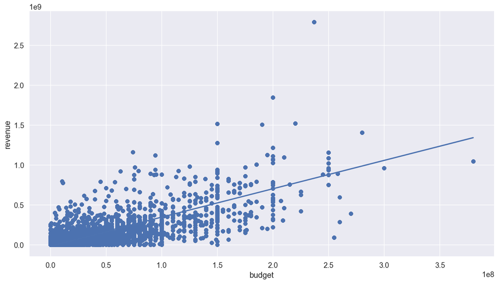

```python
#Visual 1 - Correlation between Budget and Revenue
sns.regplot(data=combined_data, x='budget', y='revenue');
```

*Answer to research question:*

The linear regression plot illustrating the relationship between budget and revenue indicates a positive correlation. Movies with larger budgets generally achieve higher revenues. This trend can be attributed to the advantages of bigger budgets, such as improved production quality, the ability to hire well-known actors, and extensive marketing efforts that draw larger audiences.

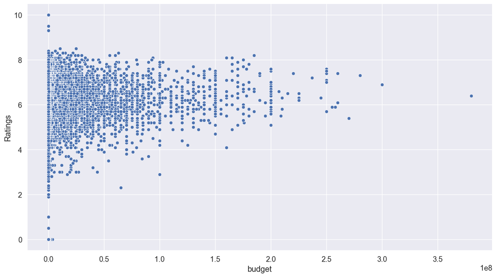

```python
#Visual 2 - Correlation between Budget and Ratings(vote_average)
sns.scatterplot(data=combined_data, x='budget', y='vote_average').set(ylabel = 'Ratings');
```

*Answer to research question:*

The relationship between a movie's budget and its ratings (vote_average) does not exhibit a strong linear correlation, unlike the trend observed with revenue. Although some high-budget movies receive high ratings, ratings vary widely across all budget levels. This indicates that a larger budget does not consistently translate to better ratings.

*Research question:* Which Movie Genre is The most popular?

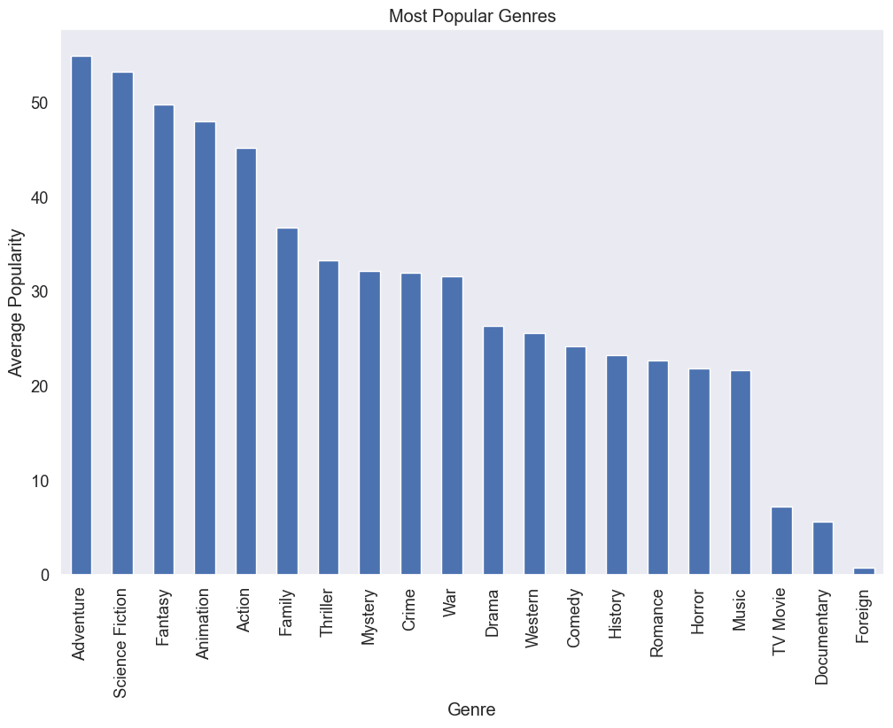

```python
#Visual 3 -The most popular genre

# Calculate the average popularity for each genre
genre_popularity = combined_data.groupby('genre')['popularity'].mean().sort_values(ascending=False)

# Bar plot of the most popular genres
plt.figure(figsize=(12, 8))
genre_popularity.plot(kind='bar')
plt.title('Most Popular Genres')
plt.xlabel('Genre')
plt.ylabel('Average Popularity')
plt.grid(False)
plt.show()
```

```python
max(genre_popularity)
```

```
55.01015448950752
```

*Answer to research question:* The most popular genre is **Adventure** with 55 average popularity.

##### Research question: What factors influence the popularity of movies? *How Average Movie Popularity distrbuted Over Time?* *Does the release-date(year) affect the popularity?*

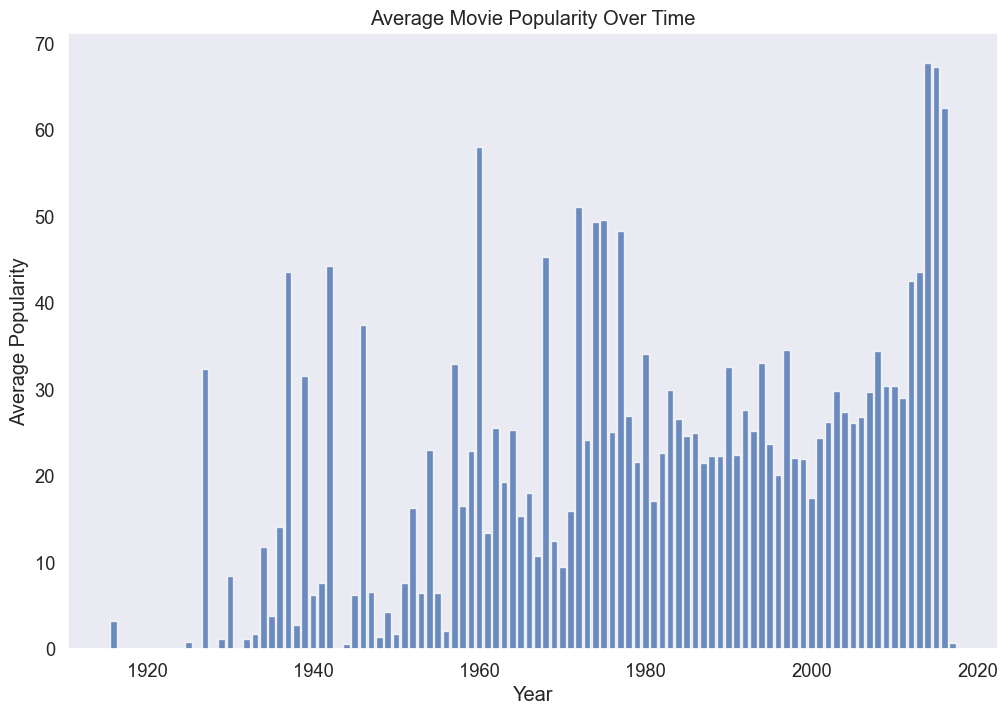

```python
#Visual 4 - Average Movie Popularity Over Time

combined_data['release_year'] = combined_data['release_date'].dt.year

popularity_by_year = combined_data.groupby('release_year')['popularity'].mean()

plt.figure(figsize=(12, 8))
plt.bar(popularity_by_year.index, popularity_by_year.values, alpha=0.8)
plt.title('Average Movie Popularity Over Time')
plt.xlabel('Year')
plt.ylabel('Average Popularity')
plt.grid(False)
plt.show()
```

*Answer to research question:*

This bar plot illustrates the average popularity of movies over time. By analyzing the plot, we can observe trends or shifts in movie popularity throughout the years. An upward or downward trend would indicate changes in the factors influencing movie popularity. Such insights can help us understand how audience preferences have evolved and provide a basis for predicting future trends in movie popularity.

Improvements in visual effects, sound quality, and cinematography over time may make newer movies more appealing, potentially skewing popularity toward recent releases.

### **5.2:** Reflection

In 2-4 sentences, if you had more time to complete the project, what actions would you take? For example, which data quality and structural issues would you look into further, and what research questions would you further explore?

*Answer:*

With additional time, I would broaden the analysis to explore various factors that influence movie success. This would include a detailed investigation into cast and crew data to evaluate the impact of specific actors, directors, and production teams on a movie's performance. Additionally, I would analyze the interaction between movie genres and other variables, such as budget and cast, to uncover combinations that consistently lead to successful outcomes.